# HW2

Zuzanna_Pirog

2022-11-01

## Wstęp

Niniejsza praca stanowi rozwiązanie zadania domowego nr 2. Jego celem było wprowadzenie poprawek do istniejącego wykresu znalezionego w prasie, telewizji lub Internecie. W czasie wybierania wykresu, który chciałabym poprawić pojawił się jeden, obok którego nie mogłam przejść obojętnie. Przedstawiał on liczbę, a właściwie procent zwycięzców losowania Ekstra Pensji z dnia 28.10.2022r. (zatem wykres pochodzi sprzed co najwyżej 2 tygodni).

Link do strony źródłowej: https://www.wynikilotto.net.pl/ekstra-pensja/wyniki/28-paz-2022/

## Pierwotny wykres

Wykres na stronie Lotto wygląda następująco:

[figure not shown]

# Poprawiony wykres

Kod do poprawionego wykresu:

Potrzebne biblioteki:

```r
library(dplyr)
library(ggplot2)
library(ggthemes)
library(forcats)
```

Dane źródłowe:

```r
df <- read.csv("EkstraPensja2.csv", sep = ";", encoding = "UTF-8")
```

Kod:

```r
df <-df %>%
  rename("Stopien" = "X.U.FEFF.Stopień") %>%
  mutate(Kwota = as.character(Kwota.PLN.))

wykres <- df %>%
  ggplot(aes(y =Combined, x = Wygrani, fill = Kwota)) +
  geom_col() +
  labs(title="Wygrani Ekstra Pensji",
       subtitle="28.10.2022r.",
       fill = "Wysokość wygranej (PLN)")+
  scale_x_continuous(expand = c(0,0),
                     limits = c(0, max(df$Wygrani)+850),
                     guide = guide_axis(angle = 45, title = "Liczba zwycięzców"),
                     breaks = seq(0, max(df$Wygrani) + 700, by = 2500))+
  scale_y_discrete(expand = c(0,0), guide = guide_axis(title = "Prawidłowe skreślenia"))+
  geom_text(aes(label = Wygrani,hjust = -0.1), size = 4) +
  theme_gdocs()+
  theme(panel.grid.major.y = element_blank(),
        plot.title = element_text(hjust = 0.5, face = "bold"),
        plot.subtitle = element_text(hjust = 0.5),
        axis.title = element_text(face = "bold", size = 15),
        legend.title = element_text(face = "bold"))+
  guides(fill = guide_legend(label.position = "left", label.hjust = 1))+
  scale_fill_manual(breaks=df$Kwota, values = c("#ffd700",
                                                "#ffb14e",
                                                "#fa8775",
                                                "#ea5f94",
                                                "#cd34b5",
                                                "#9d02d7",
                                                "#0000ff",
                                                "#042071"))
```

Gotowy wykres:

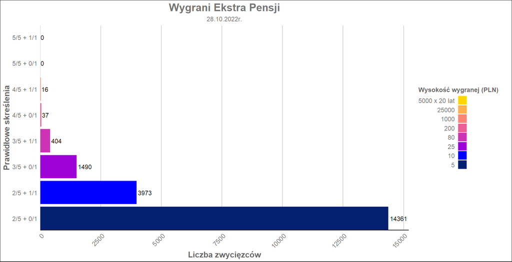

Na powyższym wykresie jesteśmy w stanie z łatwością odczytać wszystkie interesujące nas dane.

- Wykres kolumnowy, 2D pokazuje, autentyczne wysokości słupków, umiejscowienie ich w pozycji horyzontalnej, ułatwia odczytanie danych typu ciągłego, ponieważ oś x jest zdecydowanie dłuższa,
- Wszystkie osie zostały podpisane i jasno informują na jakie dane aktualnie patrzymy,
- Legenda jest wyrównana do prawej by łatwiej było odczytać wzrastające kwoty, ponadto kolory na legendzie są posortowane zgodnie z ułożeniem kolumn na wykresie,
- Wykres niesie ze sobą dużo więcej informacji, zastępuje tabelkę, która umieszczoną na stronie Lotto, odczytujemy od razu wygraną kwotę, liczbę ludzi którzy ją otrzymali oraz liczbę poprawnie odgadniętych liczb wymaganą aby ją otrzymać,
- Łatwo zauwaźyć, że najwięcej osób wygrało najniższą nagrodę pieniężną, kolumny zostały posortowane tak, by ich priorytet wzrastał wraz z osią y,
- Kolory są wyraziste i odcinają się od tła wykresu,
- Pionowe linie ułatwiają odczytanie proporcji liczby wygranych z danych kategorii,
- Z kolei boczna numeracja na słupkach umożliwia odczytanie dokładnej liczby zwycięzców, co jest szczególnie istotne w przypadku wyższych kategorii

## Podsumowanie

Wykres kolumnowy jest lepszą formą przedstawienia danych z wykresu kołowego. Jesteśmy w stanie lepiej odczytać autentyczne proprcje i wysokości słupków. Dodatkowo, dzięki dobrze opisanej legendzie możemy przenieść na wykres więcej danych, wyciągnąć więcej wniosków i w bardziej obrazowy sposób przedstawić wyniki losowania.